# Projeto Final AEM II

André Dambry, Mainara Cardoso, Tiago Pardo

2023-12-02

## Objetivo:

### 1) Utilizar métodos de aprendizagem supervisionada (regressão ou classificação)

### 2) Realização de análise de um problema não supervisionado

## Base de dados:

### Marketing Analytics

https://www.kaggle.com/datasets/jackdaoud/marketing-data/data?select=dictionary.png

A base de dados contém informações de 2206 clientes de uma empresa. Os dados são relacionados à:

- Perfil dos clientes
- Produtos
- Campanhas bem / mau sucedidas
- Performance do canal

# Proposta de Valor

Através dos modelos supervisionados, nossa proposta é dentificar chance de clientes aderirem às campanhas.

Com isto feito, nossa proposta, através do método KMeans será realizar o agrupamento de clientes. Isso é útil para que a realização de segmentação de público em campanhas de marketing.

## Modelos supervisionados:

Tipo de Problema: Classificação

Modelos:

- Regressão Logística
- Floresta Aleatória
- Boosting
- Lasso
- Ridge
- Rede Neural

## Modelos não supervisionados:

- KMeans

# Bibliotecas

```r
#install.packages("summarytools")
#install.packages("reticulate")
#install.packages("keras")
#install.packages("imbalance")
#install.packages("DMwR")
#install.packages("Rtools")
#install.packages( "Path/To/DMwR_0.4.1.tar.gz", repos=NULL, type="source" )
#install.packages("caret")
```

```r
library (readr)
library (dplyr)
library (tidyr)
library (tidyverse)
```

```r
library (skimr)
library (ggplot2)
library (summarytools)
library (tidymodels)
```

```
## • Search for functions across packages at https://www.tidymodels.org/find/
```

```r
library (ISLR)
library (doParallel)
library (glmnet)
library (ranger)
library (parsnip)
library (vip)
library(keras)
```

```r
library(corrplot)
library(imbalance)
library(DMwR2)
library(tensorflow)
library(caret)
```

# Importação de dados

```r
urlfile <- "https://raw.githubusercontent.com/nailson/ifood-data-business-analyst-test/master/ifood_df.csv"
dados <- read_csv(url(urlfile))
```

# Geração de metadados

```r
metadata <- dados  %>%
  lapply(type_sum) %>%
  as_tibble() %>%
  pivot_longer(cols = 1:ncol(dados),
               names_to = "Coluna",
               values_to = "Tipo") %>%
  inner_join(
    dados %>%
      summarise(across(everything(), ~sum(is.na(.)))) %>%
      pivot_longer(cols = 1:ncol(dados),
                   names_to = "Coluna",
                   values_to = "Total NA")
  )
metadata
```

```
## # A tibble: 39 × 3
##    Coluna           Tipo  `Total NA`
##    <chr>            <chr>      <int>
##  1 Income           dbl            0
##  2 Kidhome          dbl            0
##  3 Teenhome         dbl            0
##  4 Recency          dbl            0
##  5 MntWines         dbl            0
##  6 MntFruits        dbl            0
##  7 MntMeatProducts  dbl            0
##  8 MntFishProducts  dbl            0
##  9 MntSweetProducts dbl            0
## 10 MntGoldProds     dbl            0
## # ℹ 29 more rows
```

# 1. Tratamento

```r
summary(dados)
```

```
##      Income          Kidhome          Teenhome         Recency
##  Min.   :  1730   Min.   :0.0000   Min.   :0.0000   Min.   : 0.00
##  1st Qu.: 35196   1st Qu.:0.0000   1st Qu.:0.0000   1st Qu.:24.00
##  Median : 51287   Median :0.0000   Median :0.0000   Median :49.00
##  Mean   : 51622   Mean   :0.4422   Mean   :0.5066   Mean   :49.01
##  3rd Qu.: 68281   3rd Qu.:1.0000   3rd Qu.:1.0000   3rd Qu.:74.00
##  Max.   :113734   Max.   :2.0000   Max.   :2.0000   Max.   :99.00
##     MntWines        MntFruits     MntMeatProducts  MntFishProducts
##  Min.   :   0.0   Min.   :  0.0   Min.   :   0.0   Min.   :  0.00
##  1st Qu.:  24.0   1st Qu.:  2.0   1st Qu.:  16.0   1st Qu.:  3.00
##  Median : 178.0   Median :  8.0   Median :  68.0   Median : 12.00
##  Mean   : 306.2   Mean   : 26.4   Mean   : 165.3   Mean   : 37.76
##  3rd Qu.: 507.0   3rd Qu.: 33.0   3rd Qu.: 232.0   3rd Qu.: 50.00
##  Max.   :1493.0   Max.   :199.0   Max.   :1725.0   Max.   :259.00
##  MntSweetProducts  MntGoldProds    NumDealsPurchases NumWebPurchases
##  Min.   :  0.00   Min.   :  0.00   Min.   : 0.000    Min.   : 0.000
##  1st Qu.:  1.00   1st Qu.:  9.00   1st Qu.: 1.000    1st Qu.: 2.000
##  Median :  8.00   Median : 25.00   Median : 2.000    Median : 4.000
##  Mean   : 27.13   Mean   : 44.06   Mean   : 2.318    Mean   : 4.101
##  3rd Qu.: 34.00   3rd Qu.: 56.00   3rd Qu.: 3.000    3rd Qu.: 6.000
##  Max.   :262.00   Max.   :321.00   Max.   :15.000    Max.   :27.000
##  NumCatalogPurchases NumStorePurchases NumWebVisitsMonth  AcceptedCmp3
##  Min.   : 0.000      Min.   : 0.000    Min.   : 0.000    Min.   :0.00000
##  1st Qu.: 0.000      1st Qu.: 3.000    1st Qu.: 3.000    1st Qu.:0.00000
##  Median : 2.000      Median : 5.000    Median : 6.000    Median :0.00000
##  Mean   : 2.645      Mean   : 5.824    Mean   : 5.337    Mean   :0.07392
##  3rd Qu.: 4.000      3rd Qu.: 8.000    3rd Qu.: 7.000    3rd Qu.:0.00000
##  Max.   :28.000      Max.   :13.000    Max.   :20.000    Max.   :1.00000
##   AcceptedCmp4      AcceptedCmp5      AcceptedCmp1     AcceptedCmp2
##  Min.   :0.00000   Min.   :0.00000   Min.   :0.0000   Min.   :0.00000
##  1st Qu.:0.00000   1st Qu.:0.00000   1st Qu.:0.0000   1st Qu.:0.00000
##  Median :0.00000   Median :0.00000   Median :0.0000   Median :0.00000
##  Mean   :0.07438   Mean   :0.07302   Mean   :0.0644   Mean   :0.01361
##  3rd Qu.:0.00000   3rd Qu.:0.00000   3rd Qu.:0.0000   3rd Qu.:0.00000
##  Max.   :1.00000   Max.   :1.00000   Max.   :1.0000   Max.   :1.00000
##     Complain       Z_CostContact   Z_Revenue     Response          Age
##  Min.   :0.00000   Min.   :3     Min.   :11   Min.   :0.000   Min.   :24.0
##  1st Qu.:0.00000   1st Qu.:3     1st Qu.:11   1st Qu.:0.000   1st Qu.:43.0
##  Median :0.00000   Median :3     Median :11   Median :0.000   Median :50.0
##  Mean   :0.00907   Mean   :3     Mean   :11   Mean   :0.151   Mean   :51.1
```

[output cut: 15 more lines]

```
##  Max.   :1.0000   Max.   :1.00000   Max.   :1.0000     Max.   :1.00000
##  education_Graduation education_Master education_PhD       MntTotal
##  Min.   :0.0000       Min.   :0.0000   Min.   :0.0000   Min.   :   4.0
##  1st Qu.:0.0000       1st Qu.:0.0000   1st Qu.:0.0000   1st Qu.:  56.0
##  Median :1.0000       Median :0.0000   Median :0.0000   Median : 343.0
##  Mean   :0.5048       Mean   :0.1651   Mean   :0.2159   Mean   : 562.8
##  3rd Qu.:1.0000       3rd Qu.:0.0000   3rd Qu.:0.0000   3rd Qu.: 964.0
##  Max.   :1.0000       Max.   :1.0000   Max.   :1.0000   Max.   :2491.0
##  MntRegularProds  AcceptedCmpOverall
##  Min.   :-283.0   Min.   :0.0000
##  1st Qu.:  42.0   1st Qu.:0.0000
##  Median : 288.0   Median :0.0000
##  Mean   : 518.7   Mean   :0.2993
##  3rd Qu.: 884.0   3rd Qu.:0.0000
##  Max.   :2458.0   Max.   :4.0000
```

Verificando ausência de valores

```r
colSums(is.na(dados))
```

```
##               Income              Kidhome             Teenhome
##                    0                    0                    0
##              Recency             MntWines            MntFruits
##                    0                    0                    0
##      MntMeatProducts      MntFishProducts     MntSweetProducts
##                    0                    0                    0
##         MntGoldProds    NumDealsPurchases      NumWebPurchases
##                    0                    0                    0
##  NumCatalogPurchases    NumStorePurchases    NumWebVisitsMonth
##                    0                    0                    0
##         AcceptedCmp3         AcceptedCmp4         AcceptedCmp5
##                    0                    0                    0
##         AcceptedCmp1         AcceptedCmp2             Complain
##                    0                    0                    0
##        Z_CostContact            Z_Revenue             Response
##                    0                    0                    0
##                  Age        Customer_Days     marital_Divorced
##                    0                    0                    0
##      marital_Married       marital_Single     marital_Together
##                    0                    0                    0
##        marital_Widow   education_2n Cycle      education_Basic
##                    0                    0                    0
## education_Graduation     education_Master        education_PhD
##                    0                    0                    0
##             MntTotal      MntRegularProds   AcceptedCmpOverall
##                    0                    0                    0
```

A base de dados não possui valores ausentes.

Verificando o tipo de dados de cada coluna.

```r
sapply(dados, class)
```

```
##               Income              Kidhome             Teenhome
##            "numeric"            "numeric"            "numeric"
##              Recency             MntWines            MntFruits
##            "numeric"            "numeric"            "numeric"
##      MntMeatProducts      MntFishProducts     MntSweetProducts
##            "numeric"            "numeric"            "numeric"
##         MntGoldProds    NumDealsPurchases      NumWebPurchases
##            "numeric"            "numeric"            "numeric"
##  NumCatalogPurchases    NumStorePurchases    NumWebVisitsMonth
##            "numeric"            "numeric"            "numeric"
##         AcceptedCmp3         AcceptedCmp4         AcceptedCmp5
##            "numeric"            "numeric"            "numeric"
##         AcceptedCmp1         AcceptedCmp2             Complain
##            "numeric"            "numeric"            "numeric"
##        Z_CostContact            Z_Revenue             Response
##            "numeric"            "numeric"            "numeric"
##                  Age        Customer_Days     marital_Divorced
##            "numeric"            "numeric"            "numeric"
##      marital_Married       marital_Single     marital_Together
##            "numeric"            "numeric"            "numeric"
##        marital_Widow   education_2n Cycle      education_Basic
##            "numeric"            "numeric"            "numeric"
## education_Graduation     education_Master        education_PhD
##            "numeric"            "numeric"            "numeric"
##             MntTotal      MntRegularProds   AcceptedCmpOverall
##            "numeric"            "numeric"            "numeric"
```

Observa-se que todos as colunas são do tipo numérica. Isso ocorre porque as variáveis categóricas, como estado civil (marital) e nível de educação (education), já estão convertidas para dummy.

Verificando valores negativos.

```r
sapply(dados, function(x) sum(x < 0))
```

```
##               Income              Kidhome             Teenhome
##                    0                    0                    0
##              Recency             MntWines            MntFruits
##                    0                    0                    0
##      MntMeatProducts      MntFishProducts     MntSweetProducts
##                    0                    0                    0
##         MntGoldProds    NumDealsPurchases      NumWebPurchases
##                    0                    0                    0
##  NumCatalogPurchases    NumStorePurchases    NumWebVisitsMonth
##                    0                    0                    0
##         AcceptedCmp3         AcceptedCmp4         AcceptedCmp5
##                    0                    0                    0
##         AcceptedCmp1         AcceptedCmp2             Complain
##                    0                    0                    0
##        Z_CostContact            Z_Revenue             Response
##                    0                    0                    0
##                  Age        Customer_Days     marital_Divorced
##                    0                    0                    0
##      marital_Married       marital_Single     marital_Together
##                    0                    0                    0
##        marital_Widow   education_2n Cycle      education_Basic
##                    0                    0                    0
## education_Graduation     education_Master        education_PhD
##                    0                    0                    0
##             MntTotal      MntRegularProds   AcceptedCmpOverall
##                    0                    3                    0
```

A variável “MntRegularProds”, que representa os gastos com produtos regulares, é a única que apresenta valores negativos.

Verificando colunas com valores únicos.

```r
col_valores_unicos <- sapply(dados, function(x) length(unique(x)) == 1)
names(dados)[col_valores_unicos]
```

```
## [1] "Z_CostContact" "Z_Revenue"
```

As colunas “Z_CostContact” e “Z_Revenue”, que representam, respectivamente, o custo do contato e o valor da receita, possuem um único valor em todas as observações.

Assim, pontos a serem destacados sobre a análise inicial dos dados.

1. Ausência de valores vazios.
2. Tipo dos dados estão corretos.
3. Variáveis categóricas estão previamente tratadas como dummies.
4. A coluna “MntRegularProds” possui valores negativos.
5. As colunas “Z_CostContact” e “Z_Revenue” possuem um único valor em todas as observações.

## 1.1. Limpeza

Na análise realizada, indentificamos que a variável “MntRegularProds”, que indica o valor das compras efetuadas na plataforma, possui 3 valores negativos. Considerando que os valores das compras não podem ser negativos por natureza e que o número de observações com essa característica é pequeno, optamos por remover esses dados da base.

```r
# filtrando valores negativos da base
dados <- dados %>%
            filter (dados$MntRegularProds > 0)
```

As colunas “Z_CostContact” e “Z_Revenue”, que representam, respectivamente, o custo do contato e o valor da receita, possuem um único valor em todas as observações. Logo, essas colunas não contribuem com informações úteis para aprimorar a precisão dos modelos preditivos ou da segmentação dos clientes. Portanto, estas variáveis serão excluídas da base.

```r
col_rem <- c("Z_CostContact", "Z_Revenue")

dados <- dados %>% select(-one_of(col_rem))
```

```r
dados
```

```
## # A tibble: 2,200 × 37
##    Income Kidhome Teenhome Recency MntWines MntFruits MntMeatProducts
##     <dbl>   <dbl>    <dbl>   <dbl>    <dbl>     <dbl>           <dbl>
##  1  58138       0        0      58      635        88             546
##  2  46344       1        1      38       11         1               6
##  3  71613       0        0      26      426        49             127
##  4  26646       1        0      26       11         4              20
##  5  58293       1        0      94      173        43             118
##  6  62513       0        1      16      520        42              98
##  7  55635       0        1      34      235        65             164
##  8  33454       1        0      32       76        10              56
##  9  30351       1        0      19       14         0              24
## 10   5648       1        1      68       28         0               6
## # ℹ 2,190 more rows
## # ℹ 30 more variables: MntFishProducts <dbl>, MntSweetProducts <dbl>,
## #   MntGoldProds <dbl>, NumDealsPurchases <dbl>, NumWebPurchases <dbl>,
## #   NumCatalogPurchases <dbl>, NumStorePurchases <dbl>,
## #   NumWebVisitsMonth <dbl>, AcceptedCmp3 <dbl>, AcceptedCmp4 <dbl>,
## #   AcceptedCmp5 <dbl>, AcceptedCmp1 <dbl>, AcceptedCmp2 <dbl>, Complain <dbl>,
## #   Response <dbl>, Age <dbl>, Customer_Days <dbl>, marital_Divorced <dbl>, …
```

## 1.2. Análise de outliers

Para melhor funcionamento dos modelos, verificaremos a existência de outliers nas colunas com valores numéricos.

Obs: Não consideramos colunas com valores numéricos binários ou que não façam sentido de terem seus outliers analisados.

Verificando colunas com dados binários.

```r
colunas_binarias <- sapply(dados, function(x) length(unique(x)) == 2)
names(dados)[colunas_binarias]
```

```
##  [1] "AcceptedCmp3"         "AcceptedCmp4"         "AcceptedCmp5"
##  [4] "AcceptedCmp1"         "AcceptedCmp2"         "Complain"
##  [7] "Response"             "marital_Divorced"     "marital_Married"
## [10] "marital_Single"       "marital_Together"     "marital_Widow"
## [13] "education_2n Cycle"   "education_Basic"      "education_Graduation"
## [16] "education_Master"     "education_PhD"
```

```r
# Selecionar colunas não-binárias
colunas_nao_binarias <- names(dados)[!colunas_binarias]

# Cálculo de outliers

for (coluna in colunas_nao_binarias) {
  q1 <- quantile(dados[[coluna]], 0.25)
  q3 <- quantile(dados[[coluna]], 0.75)
  q95 <- quantile(dados[[coluna]], 0.95)
  iqr <- q3 - q1
  median <- median(dados[[coluna]])
  outlier_limit <- median + 1.5 * iqr
  # Count the number of values above the limit
  outlier_count <- sum(dados[[coluna]] > outlier_limit)
  cat(sprintf('%20s | median+1.5xiqr: %8.2f | 95quantile: %8.2f | outliers: %d\n',
              coluna, outlier_limit, q95, outlier_count))
}
```

```
##               Income | median+1.5xiqr: 100853.25 | 95quantile: 83829.40 | outliers: 5
##              Kidhome | median+1.5xiqr:     1.50 | 95quantile:     1.00 | outliers: 46
##             Teenhome | median+1.5xiqr:     1.50 | 95quantile:     1.00 | outliers: 50
##              Recency | median+1.5xiqr:   124.00 | 95quantile:    94.00 | outliers: 0
##             MntWines | median+1.5xiqr:   903.88 | 95quantile:  1001.00 | outliers: 175
##            MntFruits | median+1.5xiqr:    54.50 | 95quantile:   122.05 | outliers: 361
##      MntMeatProducts | median+1.5xiqr:   392.38 | 95quantile:   685.10 | outliers: 335
##      MntFishProducts | median+1.5xiqr:    82.50 | 95quantile:   169.10 | outliers: 356
##     MntSweetProducts | median+1.5xiqr:    57.50 | 95quantile:   126.00 | outliers: 354
##         MntGoldProds | median+1.5xiqr:    95.50 | 95quantile:   163.00 | outliers: 312
##    NumDealsPurchases | median+1.5xiqr:     5.00 | 95quantile:     6.00 | outliers: 142
##      NumWebPurchases | median+1.5xiqr:    10.00 | 95quantile:     9.00 | outliers: 45
##  NumCatalogPurchases | median+1.5xiqr:     8.00 | 95quantile:     8.00 | outliers: 109
##    NumStorePurchases | median+1.5xiqr:    12.50 | 95quantile:    12.00 | outliers: 83
##    NumWebVisitsMonth | median+1.5xiqr:    12.00 | 95quantile:     8.00 | outliers: 8
##                  Age | median+1.5xiqr:    77.00 | 95quantile:    70.00 | outliers: 2
##        Customer_Days | median+1.5xiqr:  3038.50 | 95quantile:  2826.00 | outliers: 0
##             MntTotal | median+1.5xiqr:  1706.50 | 95quantile:  1698.05 | outliers: 108
##      MntRegularProds | median+1.5xiqr:  1554.88 | 95quantile:  1648.00 | outliers: 137
##   AcceptedCmpOverall | median+1.5xiqr:     0.00 | 95quantile:     2.00 | outliers: 457
```

Verificando distribuição dos dados com gráficos Bloxplot

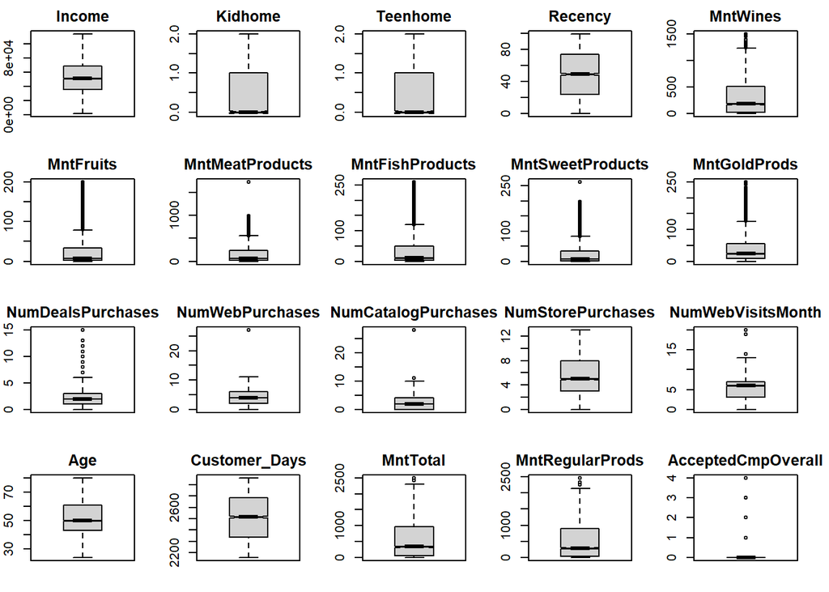

```r
# Configuração de layout para exibir 4x5 boxplots
par(mfrow = c(4, 5), mar = c(2, 2, 2, 2))

#Plot dos boxplots
for (coluna in colunas_nao_binarias) {
  boxplot(dados[[coluna]], main = coluna, coluna = "lightblue", border = "black", notch = TRUE)
}
```

# 2. Análise Exploratória de Dados

```r
# Contagem de frequências para cada campanha
cat("AcceptedCmp1\n")
```

```
## AcceptedCmp1
```

```r
print(table(dados$AcceptedCmp1))
```

```
##
##    0    1
## 2058  142
```

```r
cat("\nAcceptedCmp2\n")
```

```
##
## AcceptedCmp2
```

```r
print(table(dados$AcceptedCmp2))
```

```
##
##    0    1
## 2170   30
```

```r
cat("\nAcceptedCmp3\n")
```

```
##
## AcceptedCmp3
```

```r
print(table(dados$AcceptedCmp3))
```

```
##
##    0    1
## 2038  162
```

```r
cat("\nAcceptedCmp4\n")
```

```
##
## AcceptedCmp4
```

```r
print(table(dados$AcceptedCmp4))
```

```
##
##    0    1
## 2036  164
```

```r
cat("\nAcceptedCmp5\n")
```

```
##
## AcceptedCmp5
```

```r
print(table(dados$AcceptedCmp5))
```

```
##
##    0    1
## 2039  161
```

```r
cat("\nResponse\n")
```

```
##
## Response
```

```r
print(table(dados$Response))
```

```
##
##    0    1
## 1867  333
```

Conforme observado, em todas as campanhas realizadas, o percentual de aceitação da campanha é muito inferior ao percentual de não aceitação, inclusive no caso da variável “Response”. Esse desbalanceamento dos dados pode ocasionar problemas na previsão do modelo, visto que o modelo pode apresentar um erro maior na classificação da classe minoritária e, ainda assim, apresentar uma alta acurácia do modelo.

Dessa forma, é importante entender o efeito do falso positivo e do falso negativo para o cenário analisado. Como o objetivo da nossa previsão é decidir se compensa enviar ou não a sexta campanha de marketing para um cliente, então as consequências de uma classificação errada para o cliente são:

- Falso negativo, que seria uma previsão errada de que um cliente não vai aceitar a campanha, é um custo de oportunidade.
- Falso positivo, que seria uma previsão errada de que um cliente vai aceitar a campanha, implica no custo do envio da proposta de marketing.

# Tratamento do deslabalanceamento de dados

# Tentativa 1:

Oversampling:

Majority Weighted Minority Oversampling TEchnique

```r
#dados$Response <- as.factor(dados$Response)
```

```r
#sapply(dados, class)
```

```r
# instalar e carregar o pacote 'DMwR' que contém a função SMOTE
# install.packages("DMwR")
# instalar o pacote smotefamily
#install.packages("smotefamily")
#library(smotefamily)
```

```r
# Aplicar SMOTE
#dados_smote <- SMOTE(Response ~ ., dados, perc.over = 100*(1867/333 - 1))
```

## 2. Separação entre treino e teste

```r
split <- initial_split(dados, prop = 0.7, strata = "Response")

treinamento <- training(split)
teste <- testing(split)
```

# 3. Modelagem Estatística

Utilizaremos Tidy Models para os modelos que o comportam

```r
receita <- recipe(Response ~ ., treinamento) %>% # define a receita, com a variavel resposta e os dados de treinamento
  step_mutate(Response = as.factor(Response)) %>%
  step_normalize(all_numeric())  #normaliza todas variaveis numericas
  #step_normalize(all_of(c("MntTotal", "MntRegularProds", "MntWines",
  #                                "MntFruits", "MntMeatProducts", "MntFishProducts",
  #                                "MntSweetProducts", "MntGoldProds", "NumDealsPurchases",
  #                                "NumCatalogPurchases", "NumStorePurchases", "NumWebPurchases")))  # normaliza as variaveis não binárias com maior número de outliers
# transformando variável resposta em fator
```

```r
receita_prep <- prep(receita) # prepara a receita definida acima

treinamento_proc <- bake(receita_prep, new_data = NULL) # obtem os dados de treinamento processados

teste_proc <- bake(receita_prep, new_data = teste) # obtem os dados de teste processados
```

## 3.1. Modelos Supervisionados

# 3.1.1. Regressão Logística

Definindo modelo, engine e realizando o fit

```r
fit_glm <- logistic_reg() %>%
  set_engine("glm") %>%
  set_mode("classification") %>%
  fit(Response ~ ., treinamento_proc)


tidy(fit_glm) # estimativas do modelo ajustado em formato tidy
```

```
## # A tibble: 37 × 5
##    term             estimate std.error statistic  p.value
##    <chr>               <dbl>     <dbl>     <dbl>    <dbl>
##  1 (Intercept)       -2.87       0.147   -19.6   3.22e-85
##  2 Income             0.441      0.249     1.77  7.68e- 2
##  3 Kidhome            0.0570     0.145     0.394 6.94e- 1
##  4 Teenhome          -0.482      0.139    -3.46  5.46e- 4
##  5 Recency           -0.823      0.104    -7.88  3.23e-15
##  6 MntWines          -0.312      0.175    -1.78  7.48e- 2
##  7 MntFruits          0.108      0.114     0.947 3.44e- 1
##  8 MntMeatProducts    0.498      0.144     3.45  5.54e- 4
##  9 MntFishProducts   -0.0365     0.128    -0.284 7.76e- 1
## 10 MntSweetProducts  -0.0433     0.122    -0.355 7.22e- 1
## # ℹ 27 more rows
```

Criando Tibble com resultado

```r
fitted <- fit_glm %>%
  predict(new_data = teste_proc, type = "prob") %>% # realiza predicao para os dados de teste
  mutate(observado = teste_proc$Response, # cria uma coluna com o valor observado de default
         modelo = "logistica") # cria uma coluna para indicar qual o modelo ajustado

head(fitted) # mostra as 6 primeiras linhas do tibble criado
```

```
## # A tibble: 6 × 4
##   .pred_0 .pred_1 observado modelo
##     <dbl>   <dbl> <fct>     <chr>
## 1  0.984  0.0160  0         logistica
## 2  0.994  0.00572 0         logistica
## 3  0.945  0.0549  0         logistica
## 4  0.0752 0.925   1         logistica
## 5  0.925  0.0746  0         logistica
## 6  0.938  0.0617  0         logistica
```

### 2.1.2. LASSO

Criando o modelo

```r
lasso <- logistic_reg(penalty = tune(), mixture = 1) %>% # define o modelo lasso e o parametro a ser tunado (o lambda)
  set_engine("glmnet") %>% # define a engine do modelo
  set_mode("classification") # define que e'  problema de classificacao
```

Validação Cruzada

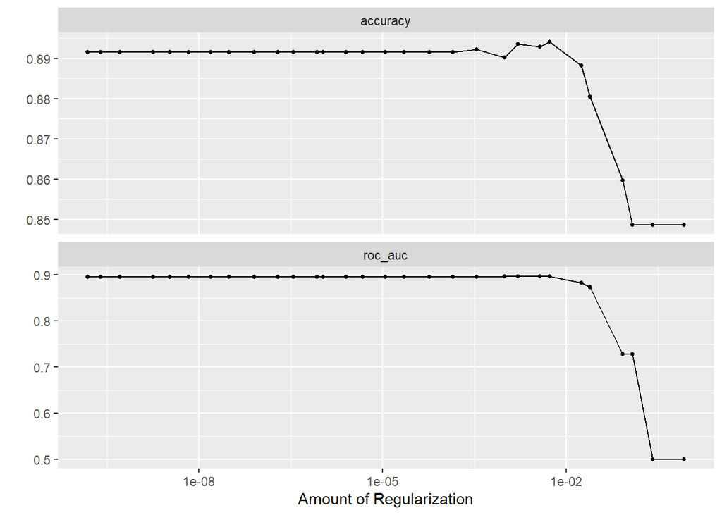

```r
set.seed(321)

cv_split <- vfold_cv(treinamento, v = 10, strata = "Response")

doParallel::registerDoParallel() # paraleliza os proximos comandos

lambda_tune <- tune_grid(lasso, # especificacao do modelo
                         receita,# a receita a ser aplicada a cada lote
                         resamples = cv_split, # os lotes da validacao cruzada
                         grid = 30,# quantas combinacoes de parametros vamos considerar
                         metrics = metric_set(roc_auc, accuracy)) # metricas consideradas

autoplot(lambda_tune) # plota os resultados
```

```r
lambda_tune %>%
  collect_metrics() # obtem as metricas calculadas
```

```
## # A tibble: 60 × 7
##     penalty .metric  .estimator  mean     n std_err .config
##       <dbl> <chr>    <chr>      <dbl> <int>   <dbl> <chr>
##  1 1.53e-10 accuracy binary     0.892    10 0.00684 Preprocessor1_Model01
##  2 1.53e-10 roc_auc  binary     0.895    10 0.0118  Preprocessor1_Model01
##  3 2.49e-10 accuracy binary     0.892    10 0.00684 Preprocessor1_Model02
##  4 2.49e-10 roc_auc  binary     0.895    10 0.0118  Preprocessor1_Model02
##  5 5.16e-10 accuracy binary     0.892    10 0.00684 Preprocessor1_Model03
##  6 5.16e-10 roc_auc  binary     0.895    10 0.0118  Preprocessor1_Model03
##  7 1.79e- 9 accuracy binary     0.892    10 0.00684 Preprocessor1_Model04
##  8 1.79e- 9 roc_auc  binary     0.895    10 0.0118  Preprocessor1_Model04
##  9 3.36e- 9 accuracy binary     0.892    10 0.00684 Preprocessor1_Model05
## 10 3.36e- 9 roc_auc  binary     0.895    10 0.0118  Preprocessor1_Model05
## # ℹ 50 more rows
```

```r
best <- lambda_tune %>%
  select_best("roc_auc") # seleciona a melhor combinacao de hiperparametros

fit_lasso <- finalize_model(lasso, parameters = best) %>% # informa os valores de hiperparametros a serem considerados
  fit(Response ~ .,data = treinamento_proc) # executa o modelo com os valores de hiperparametros definidos acima
```

```r
fitted <- fitted %>% #      empilha as previsoes do lasso
  bind_rows(fit_lasso %>% # os valores preditos pelo lasso
              predict(new_data = teste_proc, type = "prob") %>%
              mutate(observado = teste_proc$Response,
                     modelo = "lasso"))

head(fitted)
```

```
## # A tibble: 6 × 4
##   .pred_0 .pred_1 observado modelo
##     <dbl>   <dbl> <fct>     <chr>
## 1  0.984  0.0160  0         logistica
## 2  0.994  0.00572 0         logistica
## 3  0.945  0.0549  0         logistica
## 4  0.0752 0.925   1         logistica
## 5  0.925  0.0746  0         logistica
## 6  0.938  0.0617  0         logistica
```

```r
tail(fitted)
```

```
## # A tibble: 6 × 4
##   .pred_0 .pred_1 observado modelo
##     <dbl>   <dbl> <fct>     <chr>
## 1   0.984  0.0156 0         lasso
## 2   0.849  0.151  0         lasso
## 3   0.505  0.495  0         lasso
## 4   0.966  0.0341 0         lasso
## 5   0.942  0.0581 0         lasso
## 6   0.867  0.133  1         lasso
```

### 2.1.3. Ridge

Definindo o modelo, parãmetro de tunagem e engine

```r
ridge <- logistic_reg(penalty = tune(), mixture = 0) %>%
  set_engine("glmnet") %>%
  set_mode("classification")
```

Validação Cruzada

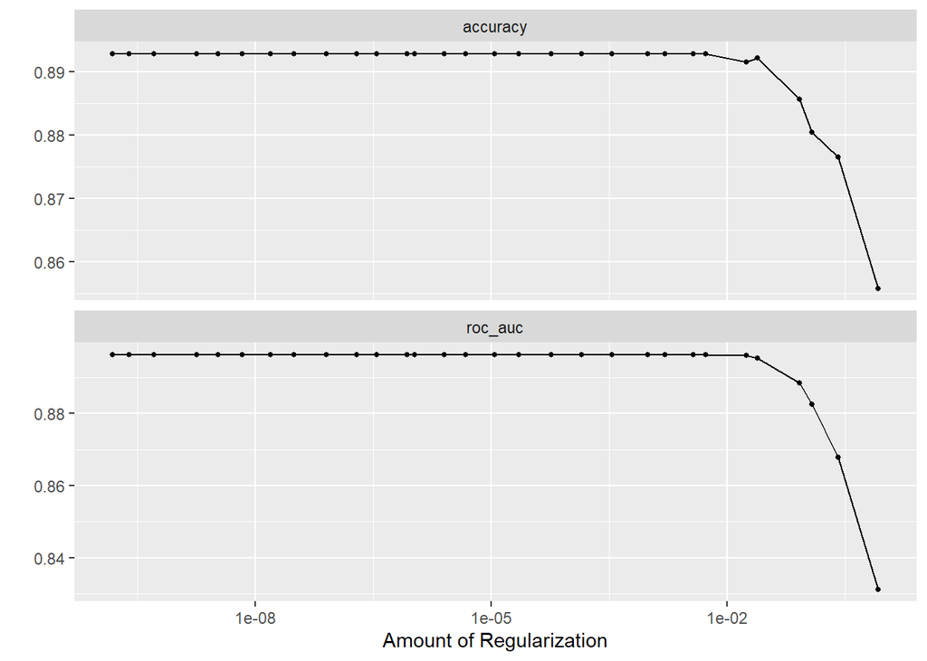

```r
set.seed(321)

cv_split <- vfold_cv(treinamento, v = 10, strata = "Response")

doParallel::registerDoParallel() # paraleliza os proximos comandos

lambda_tune <- tune_grid(ridge, # especificacao do modelo
                         receita,# a receita a ser aplicada a cada lote
                         resamples = cv_split, # os lotes da validacao cruzada
                         grid = 30,# quantas combinacoes de parametros vamos considerar
                         metrics = metric_set(roc_auc, accuracy)) # metricas consideradas

autoplot(lambda_tune) # plota os resultados
```

```r
lambda_tune %>%
  collect_metrics() # obtem as metricas calculadas
```

```
## # A tibble: 60 × 7
##     penalty .metric  .estimator  mean     n std_err .config
##       <dbl> <chr>    <chr>      <dbl> <int>   <dbl> <chr>
##  1 1.53e-10 accuracy binary     0.893    10 0.00573 Preprocessor1_Model01
##  2 1.53e-10 roc_auc  binary     0.896    10 0.0115  Preprocessor1_Model01
##  3 2.49e-10 accuracy binary     0.893    10 0.00573 Preprocessor1_Model02
##  4 2.49e-10 roc_auc  binary     0.896    10 0.0115  Preprocessor1_Model02
##  5 5.16e-10 accuracy binary     0.893    10 0.00573 Preprocessor1_Model03
##  6 5.16e-10 roc_auc  binary     0.896    10 0.0115  Preprocessor1_Model03
##  7 1.79e- 9 accuracy binary     0.893    10 0.00573 Preprocessor1_Model04
##  8 1.79e- 9 roc_auc  binary     0.896    10 0.0115  Preprocessor1_Model04
##  9 3.36e- 9 accuracy binary     0.893    10 0.00573 Preprocessor1_Model05
## 10 3.36e- 9 roc_auc  binary     0.896    10 0.0115  Preprocessor1_Model05
## # ℹ 50 more rows
```

```r
best <- lambda_tune %>%
  select_best("roc_auc") # seleciona a melhor combinacao de hiperparametros

fit_ridge <- finalize_model(ridge, parameters = best) %>% # informa os valores de hiperparametros a serem considerados
  fit(Response ~ .,data = treinamento_proc) # executa o modelo com os valores de hiperparametros definidos acima

fitted <- fitted %>% #      empilha as previsoes do lasso
  bind_rows(fit_ridge %>% # os valores preditos pelo lasso
              predict(new_data = teste_proc, type = "prob") %>%
              mutate(observado = teste_proc$Response,
                     modelo = "ridge"))

head(fitted)
```

```
## # A tibble: 6 × 4
##   .pred_0 .pred_1 observado modelo
##     <dbl>   <dbl> <fct>     <chr>
## 1  0.984  0.0160  0         logistica
## 2  0.994  0.00572 0         logistica
## 3  0.945  0.0549  0         logistica
## 4  0.0752 0.925   1         logistica
## 5  0.925  0.0746  0         logistica
## 6  0.938  0.0617  0         logistica
```

```r
tail(fitted)
```

```
## # A tibble: 6 × 4
##   .pred_0 .pred_1 observado modelo
##     <dbl>   <dbl> <fct>     <chr>
## 1   0.983  0.0166 0         ridge
## 2   0.884  0.116  0         ridge
## 3   0.527  0.473  0         ridge
## 4   0.958  0.0420 0         ridge
## 5   0.941  0.0588 0         ridge
## 6   0.867  0.133  1         ridge
```

# 3.1.4. Floresta Aleatória

Definindo o modelo, cálculo de importância das variáveis e tipo de previsão

```r
rf <- rand_forest() %>%
  set_engine("ranger",
             importance = "permutation") %>%
  set_mode("classification")

rf
```

```
## Random Forest Model Specification (classification)
##
## Engine-Specific Arguments:
##   importance = permutation
##
## Computational engine: ranger
```

Ajuste do modelo

```r
rf_fit <- rf %>%
  fit(Response ~ ., treinamento_proc)
rf_fit
```

```
## parsnip model object
##
## Ranger result
##
## Call:
##  ranger::ranger(x = maybe_data_frame(x), y = y, importance = ~"permutation",      num.threads = 1, verbose = FALSE, seed = sample.int(10^5,          1), probability = TRUE)
##
## Type:                             Probability estimation
## Number of trees:                  500
## Sample size:                      1539
## Number of independent variables:  36
## Mtry:                             6
## Target node size:                 10
## Variable importance mode:         permutation
## Splitrule:                        gini
## OOB prediction error (Brier s.):  0.0847741
```

Verificando a importância das variaveis para o modelo

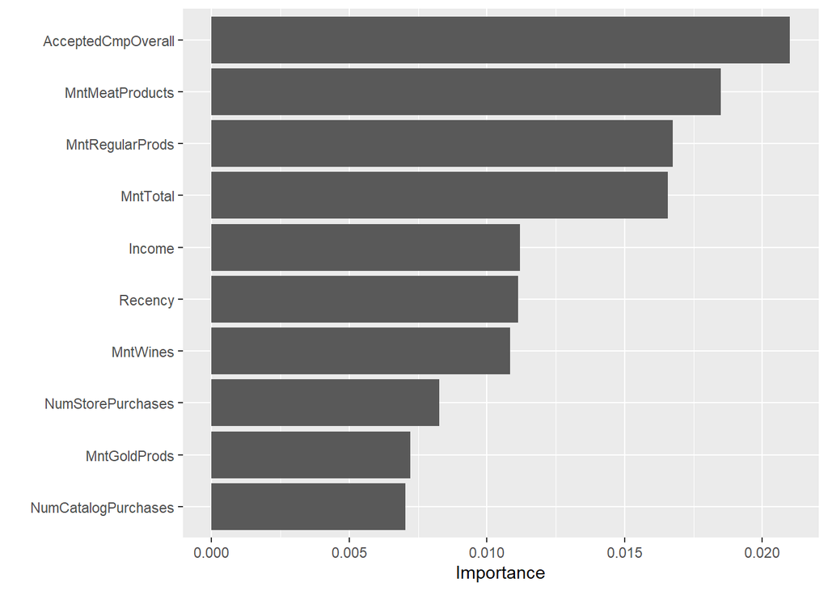

```r
vip(rf_fit)
```

```r
fitted_rf <- rf_fit %>%
  predict(new_data = teste_proc, type = 'prob') %>% # realiza predicao para os dados de teste
  mutate(observado = teste_proc$Response, # mesma estrutura do fitted_lm
         modelo = "random forest")
```

```r
fitted <- fitted %>%
  bind_rows(fitted) # empilha o tibble fitted_rf abaixo do fitted_lm

head(fitted)
```

```
## # A tibble: 6 × 4
##   .pred_0 .pred_1 observado modelo
##     <dbl>   <dbl> <fct>     <chr>
## 1  0.984  0.0160  0         logistica
## 2  0.994  0.00572 0         logistica
## 3  0.945  0.0549  0         logistica
## 4  0.0752 0.925   1         logistica
## 5  0.925  0.0746  0         logistica
## 6  0.938  0.0617  0         logistica
```

```r
tail(fitted)
```

```
## # A tibble: 6 × 4
##   .pred_0 .pred_1 observado modelo
##     <dbl>   <dbl> <fct>     <chr>
## 1   0.983  0.0166 0         ridge
## 2   0.884  0.116  0         ridge
## 3   0.527  0.473  0         ridge
## 4   0.958  0.0420 0         ridge
## 5   0.941  0.0588 0         ridge
## 6   0.867  0.133  1         ridge
```

Avaliar desempenho

Ajustando Hiperparâmetros

```r
rf2 <- rand_forest(mtry = tune(),
                   trees = tune(), # todos argumentos com tune() serao tunados a seguir
                   min_n = tune()) %>%
  set_engine("ranger") %>% #
  set_mode("classification")

rf2
```

```
## Random Forest Model Specification (classification)
##
## Main Arguments:
##   mtry = tune()
##   trees = tune()
##   min_n = tune()
##
## Computational engine: ranger
```

Realizando Validação Cruzada

```r
set.seed(123)
cv_split <- vfold_cv(treinamento, v = 10)

registerDoParallel() # pararaleliza o processo

# para tunar os parametros
rf_grid <- tune_grid(rf2, # especificacao do modelo
                     receita, # a receita a ser aplicada a cada lote
                     resamples = cv_split, # os lotes da validacao cruzada
                     grid = 10, # quantas combinacoes de parametros vamos considerar
                     metrics = metric_set(roc_auc, accuracy))
```

```
## i Creating pre-processing data to finalize unknown parameter: mtry
```

Plotando os resultados

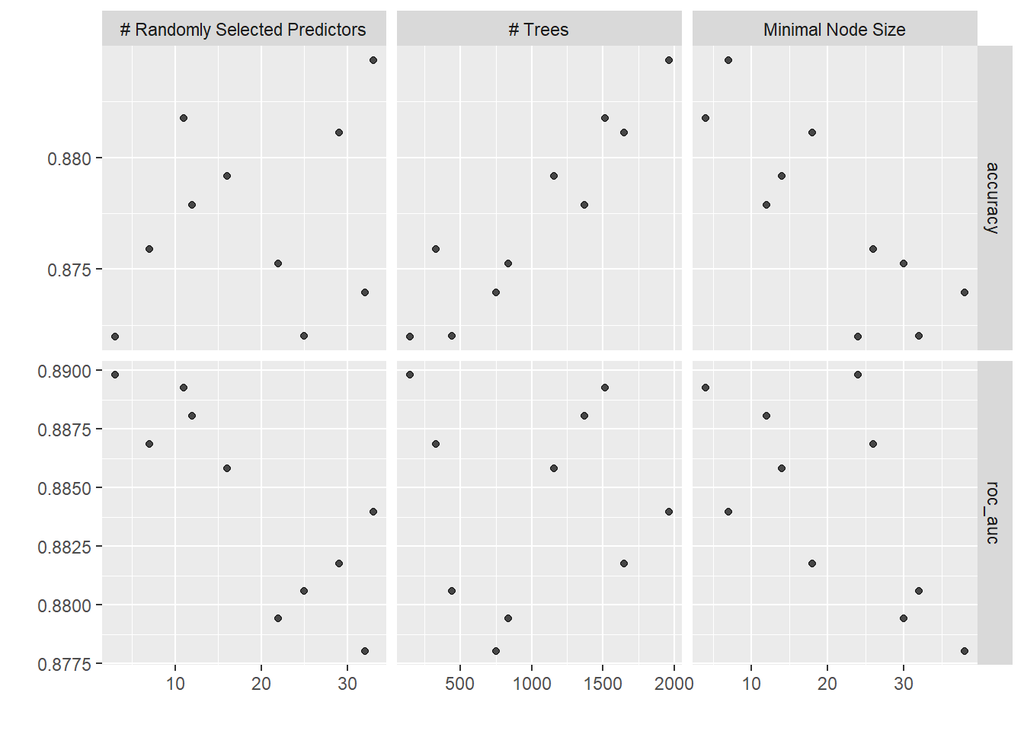

```r
autoplot(rf_grid)
```

Selecionando a melhor combinação e hiperparametros e salvando na variável

```r
rf_grid %>%
  collect_metrics()
```

```
## # A tibble: 20 × 9
##     mtry trees min_n .metric  .estimator  mean     n std_err .config
##    <int> <int> <int> <chr>    <chr>      <dbl> <int>   <dbl> <chr>
##  1    25   445    32 accuracy binary     0.872    10  0.0138 Preprocessor1_Mode…
##  2    25   445    32 roc_auc  binary     0.881    10  0.0148 Preprocessor1_Mode…
##  3    32   754    38 accuracy binary     0.874    10  0.0133 Preprocessor1_Mode…
##  4    32   754    38 roc_auc  binary     0.878    10  0.0144 Preprocessor1_Mode…
##  5    12  1370    12 accuracy binary     0.878    10  0.0131 Preprocessor1_Mode…
##  6    12  1370    12 roc_auc  binary     0.888    10  0.0141 Preprocessor1_Mode…
##  7     3   152    24 accuracy binary     0.872    10  0.0136 Preprocessor1_Mode…
##  8     3   152    24 roc_auc  binary     0.890    10  0.0146 Preprocessor1_Mode…
##  9    11  1515     4 accuracy binary     0.882    10  0.0124 Preprocessor1_Mode…
## 10    11  1515     4 roc_auc  binary     0.889    10  0.0142 Preprocessor1_Mode…
## 11    29  1649    18 accuracy binary     0.881    10  0.0133 Preprocessor1_Mode…
## 12    29  1649    18 roc_auc  binary     0.882    10  0.0144 Preprocessor1_Mode…
## 13    22   839    30 accuracy binary     0.875    10  0.0132 Preprocessor1_Mode…
## 14    22   839    30 roc_auc  binary     0.879    10  0.0147 Preprocessor1_Mode…
## 15    33  1960     7 accuracy binary     0.884    10  0.0131 Preprocessor1_Mode…
## 16    33  1960     7 roc_auc  binary     0.884    10  0.0137 Preprocessor1_Mode…
## 17    16  1158    14 accuracy binary     0.879    10  0.0127 Preprocessor1_Mode…
## 18    16  1158    14 roc_auc  binary     0.886    10  0.0143 Preprocessor1_Mode…
## 19     7   332    26 accuracy binary     0.876    10  0.0138 Preprocessor1_Mode…
## 20     7   332    26 roc_auc  binary     0.887    10  0.0143 Preprocessor1_Mode…
```

```r
best <- rf_grid %>%
  select_best("roc_auc")
```

Finalizando o modelo

```r
rf_fit2 <- finalize_model(rf2, parameters = best) %>% # informa os valores de hiperparametros a serem considerados

  fit(Response ~ ., treinamento_proc) # executa o modelo com os valores de hiperparametros definidos acima
```

Previsão para os dados de teste

```r
fitted_rf2 <- rf_fit2 %>% # faz previsao para os dados de teste
  predict(new_data = teste_proc, type = 'prob') %>%
  mutate(observado = teste_proc$Response,
         modelo = "random forest - tune")

fitted <- fitted %>%
  bind_rows(fitted_rf2)
```

esse deve ser o último snipet após realizar a tabela de resultado de todos os modelos

Redes neurais

```r
# Preparando dados

# Selecionando variáveis explicativas do treinamento e convertendo dados para matriz
X_trn <- treinamento %>%
  select(-Response) %>%
  as.matrix()
```

```r
# Selecionando variáveis explicativas do teste e convertendo dados para matriz
X_tst <- teste %>%
  select(-Response) %>%
  as.matrix()
```

```r
# Padroniza os dados de treinamento
X_trn <- scale(X_trn)

# Padroniza os dados de teste usando os mesmos parâmetros de centralização e escala dos dados de treinamento
X_tst <- scale(X_tst,
               center = attr(X_trn, "scaled:center"),
               scale = attr(X_trn, "scaled:scale"))

# Cria um modelo sequencial
net <- keras_model_sequential() %>%
    layer_dense(units = 32, activation = "relu", input_shape = ncol(X_trn)) %>% # número de características de entrada
    #layer_dropout(rate=0.4) %>%
    layer_dense(units = 16, activation = "relu") %>%
    #layer_dropout(rate=0.3) %>%
    layer_dense(units = 8, activation = "relu") %>%
    layer_dense(units = 1, activation = "sigmoid")
```

```r
library(tensorflow)
library(keras)
```

```r
# Modelo para classificação
net <- compile(net,
               loss = "binary_crossentropy",
               optimizer = "adam",
               metrics = list(metric_recall()))

# Treino dwo modelo para classificação
history_class <- fit(
  net, X_trn, treinamento$Response,
  batch_size = 16, epochs = 20,
  validation_split = 0.2)
```

```
## 77/77 - 1s - loss: 0.4760 - recall: 0.0000e+00 - val_loss: 2.3937 - val_recall: 0.0086 - 1s/epoch - 16ms/step
## 77/77 - 0s - loss: 0.0613 - recall: 0.0000e+00 - val_loss: 3.9416 - val_recall: 0.0000e+00 - 181ms/epoch - 2ms/step
## 77/77 - 0s - loss: 0.0144 - recall: 0.0000e+00 - val_loss: 4.7417 - val_recall: 0.0000e+00 - 184ms/epoch - 2ms/step
## 77/77 - 0s - loss: 0.0063 - recall: 0.0000e+00 - val_loss: 5.3073 - val_recall: 0.0000e+00 - 184ms/epoch - 2ms/step
## 77/77 - 0s - loss: 0.0035 - recall: 0.0000e+00 - val_loss: 5.7262 - val_recall: 0.0000e+00 - 190ms/epoch - 2ms/step
## 77/77 - 0s - loss: 0.0022 - recall: 0.0000e+00 - val_loss: 6.0657 - val_recall: 0.0000e+00 - 177ms/epoch - 2ms/step
## 77/77 - 0s - loss: 0.0015 - recall: 0.0000e+00 - val_loss: 6.3530 - val_recall: 0.0000e+00 - 196ms/epoch - 3ms/step
## 77/77 - 0s - loss: 0.0011 - recall: 0.0000e+00 - val_loss: 6.6027 - val_recall: 0.0000e+00 - 186ms/epoch - 2ms/step
## 77/77 - 0s - loss: 8.5179e-04 - recall: 0.0000e+00 - val_loss: 6.8184 - val_recall: 0.0000e+00 - 192ms/epoch - 2ms/step
## 77/77 - 0s - loss: 6.6542e-04 - recall: 0.0000e+00 - val_loss: 7.0229 - val_recall: 0.0000e+00 - 175ms/epoch - 2ms/step
## 77/77 - 0s - loss: 5.3208e-04 - recall: 0.0000e+00 - val_loss: 7.2058 - val_recall: 0.0000e+00 - 185ms/epoch - 2ms/step
## 77/77 - 0s - loss: 4.3368e-04 - recall: 0.0000e+00 - val_loss: 7.3731 - val_recall: 0.0000e+00 - 191ms/epoch - 2ms/step
## 77/77 - 0s - loss: 3.5970e-04 - recall: 0.0000e+00 - val_loss: 7.5271 - val_recall: 0.0000e+00 - 175ms/epoch - 2ms/step
## 77/77 - 0s - loss: 3.0243e-04 - recall: 0.0000e+00 - val_loss: 7.6679 - val_recall: 0.0000e+00 - 193ms/epoch - 3ms/step
## 77/77 - 0s - loss: 2.5754e-04 - recall: 0.0000e+00 - val_loss: 7.8031 - val_recall: 0.0000e+00 - 184ms/epoch - 2ms/step
## 77/77 - 0s - loss: 2.2164e-04 - recall: 0.0000e+00 - val_loss: 7.9305 - val_recall: 0.0000e+00 - 187ms/epoch - 2ms/step
## 77/77 - 0s - loss: 1.9212e-04 - recall: 0.0000e+00 - val_loss: 8.0489 - val_recall: 0.0000e+00 - 165ms/epoch - 2ms/step
## 77/77 - 0s - loss: 1.6793e-04 - recall: 0.0000e+00 - val_loss: 8.1613 - val_recall: 0.0000e+00 - 201ms/epoch - 3ms/step
## 77/77 - 0s - loss: 1.4772e-04 - recall: 0.0000e+00 - val_loss: 8.2725 - val_recall: 0.0000e+00 - 180ms/epoch - 2ms/step
## 77/77 - 0s - loss: 1.3070e-04 - recall: 0.0000e+00 - val_loss: 8.3764 - val_recall: 0.0000e+00 - 192ms/epoch - 2ms/step
```

Avaliando o modelo

```r
# Fazendo previsões no conjunto de teste
y_pred_prob <- predict(net, X_tst)
```

```
## 21/21 - 0s - 97ms/epoch - 5ms/step
```

```r
# Convertendo as probabilidades de previsão para classificações binárias
y_pred_class <- ifelse(y_pred_prob > 0.5, 1, 0)

# Calculando o erro
error_rate <- mean(y_pred_class != teste$Response)

conf_mat <- confusionMatrix(data = as.factor(y_pred_class), reference = as.factor(teste$Response))
# Calculando sensibilidade e especificidade diretamente
sensitivity <- caret::sensitivity(as.factor(y_pred_class), as.factor(teste$Response))
specificity <- caret::specificity(as.factor(y_pred_class), as.factor(teste$Response))
accuracy <- sum(diag(conf_mat$table)) / sum(conf_mat$table)

# Exibindo os resultados
print(paste("Erro: ", error_rate))
```

```
## [1] "Erro:  0.151285930408472"
```

```r
print(paste("Sensibilidade: ", sensitivity))
```

```
## [1] "Sensibilidade:  1"
```

```r
print(paste("Especificidade: ", specificity))
```

```
## [1] "Especificidade:  0"
```

```r
print(paste("Acurácia: ", accuracy))
```

```
## [1] "Acurácia:  0.848714069591528"
```

```r
conf_mat
```

```
## Confusion Matrix and Statistics
##
##           Reference
## Prediction   0   1
##          0 561 100
##          1   0   0
##
##                Accuracy : 0.8487
##                  95% CI : (0.8191, 0.8752)
##     No Information Rate : 0.8487
##     P-Value [Acc > NIR] : 0.5267
##
##                   Kappa : 0
##
##  Mcnemar's Test P-Value : <2e-16
##
##             Sensitivity : 1.0000
##             Specificity : 0.0000
##          Pos Pred Value : 0.8487
##          Neg Pred Value :    NaN
##              Prevalence : 0.8487
##          Detection Rate : 0.8487
##    Detection Prevalence : 1.0000
##       Balanced Accuracy : 0.5000
##
##        'Positive' Class : 0
##
```

Comparando desempenho dos modelos

```r
fitfull <- fitted %>%
  mutate(
    observado_bin = as.factor(as.numeric(observado) - 1),# Converte o fator para numérico (0 e 1)
    pred_binf = as.factor(if_else(.pred_1 > 0.5, 1, 0)),
    pred_bin = if_else(.pred_1 > 0.5, 1, 0)    # Cria previsões binárias
  ) %>%
  group_by(modelo)


sensib <- fitfull%>% sens(observado_bin, pred_binf) %>% select(.estimate) %>%
  pull(.estimate)

sensiv <- fitfull %>% spec(observado_bin, pred_binf) %>% select(.estimate)%>%
  pull(.estimate)
posit <- fitfull  %>% ppv(observado_bin, pred_binf) %>% select(.estimate)%>%
  pull(.estimate)
negativ <- fitfull  %>% npv(observado_bin, pred_binf) %>% select(.estimate)%>%
  pull(.estimate)

fitfull %>% roc_auc(observado_bin, .pred_1)  %>%
  mutate(auc = .estimate,
    sensibilidade= sensib,
        sensitividade = sensiv,
       verdposit = posit,
       verdneg = negativ) %>% select(modelo, auc, sensibilidade, sensitividade, verdposit, verdneg)
```

```
## # A tibble: 4 × 6
##   modelo                  auc sensibilidade sensitividade verdposit verdneg
##   <chr>                 <dbl>         <dbl>         <dbl>     <dbl>   <dbl>
## 1 lasso                0.0994         0.975          0.45     0.909   0.763
## 2 logistica            0.0961         0.973          0.5      0.916   0.769
## 3 random forest - tune 0.120          0.979          0.24     0.878   0.667
## 4 ridge                0.102          0.977          0.41     0.903   0.759
```